# San Francisco's BAY AREA FORD GO BIKE SHARING SERVICE

## by Mohammed Suara

## Investigation Overview

> In this investigation, I want to determine possible factors that contribute to increased usage of the service.

## Dataset Overview

> There are about 175 000 rows and 23 columns each with information about various aspects of the bike trip and the rider. Major attributes of the trip include the duration, start day, start hour. Attributes of the rider include: age, gender, user-type. There are about the same amount of numeric and non-numeric variables in the dataset.

## DISTRIBUTION OF AGE

> Least age is 21 and the highest age was 95. The distributions are right skewed with a peak at around 31 - 36 age groups.

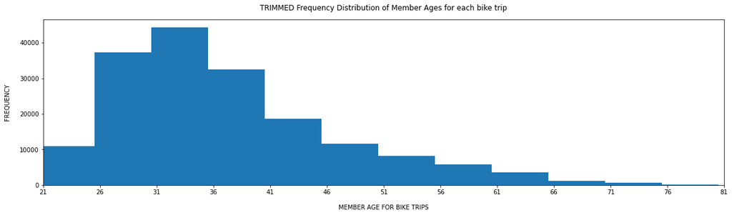

## DISTRIBUTION OF THE DURATION FOR BIKE TRIPS.

> The duration(min) posed a challenge as it showed a high range with extreme ends of values. Most of the data however fell below 40mins and the frequency distribution was accordinly transformed to reveal this important information.

> Most trips have a duration of 40mins or less with a peak at 5mins. The distribution is right skewed.

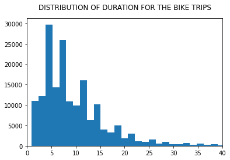

## AVERAGE DURATION SPENT BY EACH AGE GROUP.

> Suprisingly, age groups 80-89 had the highest average duration spent on trips. The middle-age groups spent on the average about a minute more the younger age groups. Rather unsuprisingly, the least average duration was spent by the 90-99 age groups.

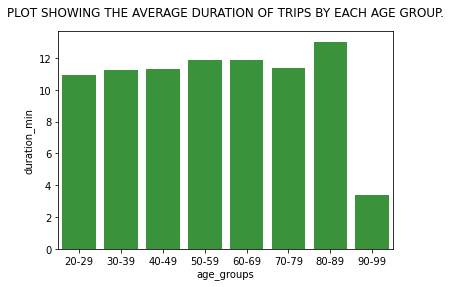

## DURATION SPENT BY EACH GENDER FOR EACH DAY OF THE WEEK.

> There was consistency in the average duration spent on trips by the genders. It was consistently "Other" > "Female" > "Male" for everyday of the week. Perhaps the Males don't fancy travelling longer trips on bikes or are able to cycle faster!

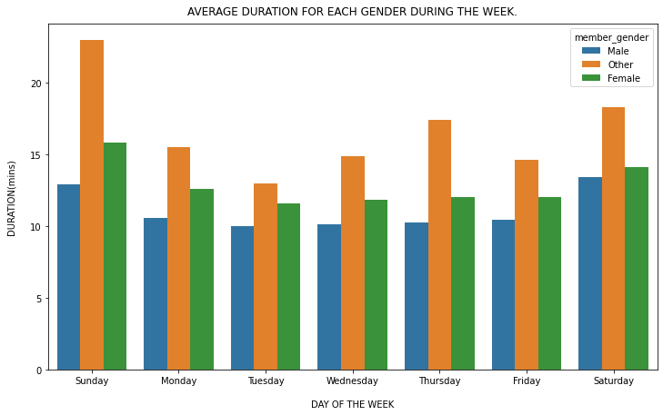